# Lab #5

Jaeyeon Won, Jay Maxwell

11/5/2020

# Load Libraries

```r
library(ggplot2)
library(tidyverse)
library(readxl)
library(lubridate)
```

# Load Data

```r
# Accident
acc = read.csv("accident.csv", stringsAsFactors = FALSE)

# Person
person = read.csv("person.csv", stringsAsFactors = FALSE)
```

# Questions

**1. Are there some days of the week where more accidents happen than the others (see FARS manual, use variable DAY_WEEK)?**

```r
# Convert DAY_WEEK from Integer to Factor
acc$DAY_WEEK = as.factor(acc$DAY_WEEK)

# Rename the levels of DAY_WEEK
levels(acc$DAY_WEEK) =  c("Sunday", "Monday", "Tuesday", "Wednesday", "Thursday", "Friday", "Saturday")

# Check the new levels of DAY_WEEK
levels(acc$DAY_WEEK)
```

```
## [1] "Sunday"    "Monday"    "Tuesday"   "Wednesday" "Thursday"  "Friday"
## [7] "Saturday"
```

```r
# Numerical summary of number of accidents on each day of the week
acc %>%
  group_by(DAY_WEEK) %>%
  summarise(total_acc = n()) %>%
  arrange(desc(total_acc))
```

```
## # A tibble: 7 x 2
##   DAY_WEEK  total_acc
##   <fct>         <int>
## 1 Saturday       5873
## 2 Sunday         5360
## 3 Friday         5358
## 4 Thursday       4621
## 5 Monday         4374
## 6 Tuesday        4347
## 7 Wednesday      4314
```

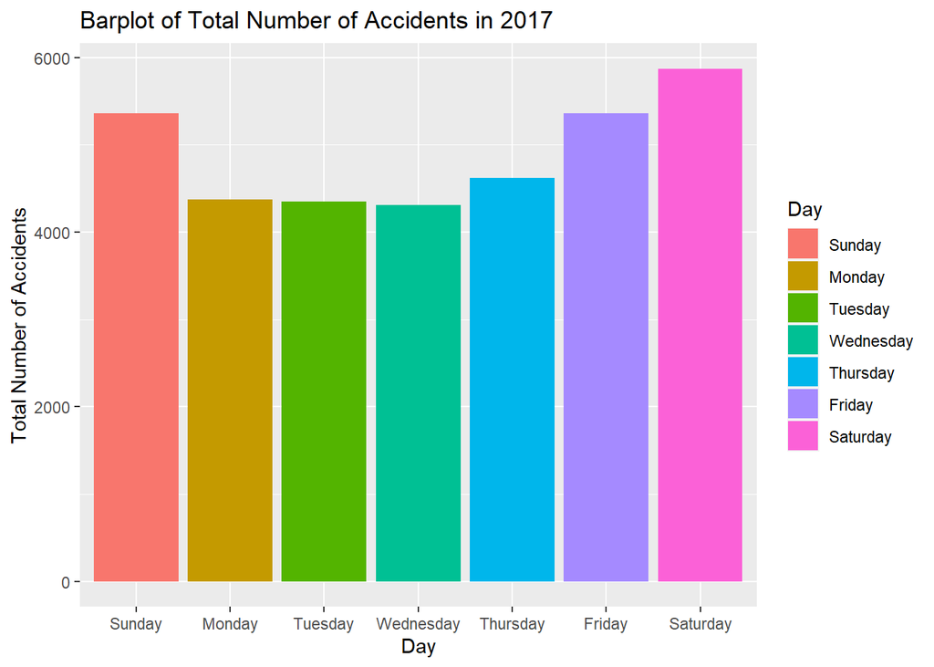

```r
# Barplot of number of accidents on each day of the week
acc %>%
  group_by(DAY_WEEK) %>%
  summarise(total_acc = n()) %>%
  ggplot(aes(x = DAY_WEEK, weight = total_acc, fill = DAY_WEEK)) +
  geom_bar() +
  ggtitle('Barplot of Total Number of Accidents in 2017') +
  xlab('Day') +
  ylab('Total Number of Accidents') +
  labs(fill = 'Day')
```

Based on both the numerical summary and visual summary, in the order of Wed, Tue, Mon, Thurs, Fri, Sun, and Sat, the total number of accidents got higher. Even though Fridays and the weekends (Sunday and Saturday) had higher number of accidents (more than 5,000 accidents) compared to other days of the week (less than 5,000 accidents), the difference of the number of accidents was not particularly enormous.

**2. Create a data frame containing the persons who are fatally hurt in the accidents (look up variable INJ_SEV)**

```r
# Create a data frame with people who were fatally hurt (INJ_SEV = 4)
person_fatal = person %>%
  filter(INJ_SEV == 4)

person_fatal %>%
  dim()
```

```
## [1] 37133    68
```

The person_fatal data frame only includes the people who were fatally injured in the accidents in 2017. This is derived by only selecting the people with “Injury Severity” of 4. This data frame now has 37133 observations and 68 variables (same variables as the original person data frame).

**3. Create a data frame containing the most dangerous vehicle make in each state. The number of persons fatally hit in the vehicle make is used to assess the (non-)safety of a make. Make sure to handle the missing values appropriately. (look up variable MAKE)**

```r
# Find the the most dangerous vehicle make in each state
danger_make = person %>%
  filter(INJ_SEV == 4) %>%
  filter(is.na(MAKE) == FALSE) %>%
  group_by(STATE, MAKE) %>%
  summarise(total_fatal_acc = n()) %>%
  group_by(STATE) %>%
  filter(total_fatal_acc == max(total_fatal_acc))

danger_make %>%
  head(5)
```

```
## # A tibble: 5 x 3
## # Groups:   STATE [5]
##   STATE  MAKE total_fatal_acc
##   <int> <int>           <int>
## 1     1    12             138
## 2     2    12               9
## 3     4    20              88
## 4     5    20              88
## 5     6    49             351
```

The danger_make data frame only includes the observations that are classified as the most dangerous vehicle make in each state. This data frame has 54 observations and 3 variables (STATE, MAKE, and total_fatal_acc). As some states had more than one car company that had the same total number of fatal accidents, there are some duplicated observations in the STATE column.

**4. Create a map, and label each state with the most dangerous vehicle. Discuss the definition of the most dangerous vehicle, and what you find from the map. (Hint: Read the description for the STATE and COUNTY columns in the FARS manual. The state & county codes are Geographic Locator Codes (GLCs) from the General Services Administration’s (GSA) publication. Use readxl::read_xlsx to read in the GLCs.)**

```r
# Load data
# glc_state
glc_state = read_xlsx('FRPP_GLC_-_United_StatesSep292020.xlsx')
# states
states = map_data('state')

# Clean data
glc_state$`State Code` = as.numeric(glc_state$`State Code`)
danger_make$MAKE = as.factor(danger_make$MAKE)

# Find which states has more than one frequencies
danger_make %>%
  group_by(STATE) %>%
  summarise(number_freq = n()) %>%
  filter(number_freq >= 2)
```

```
## # A tibble: 3 x 2
##   STATE number_freq
##   <int>       <int>
## 1     8           2
## 2    34           2
## 3    50           2
```

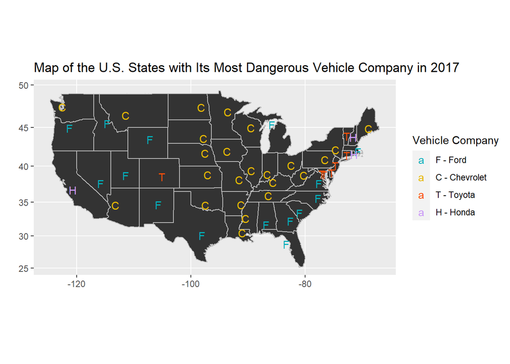

```r
# Select only one MAKE for state = 8, 34, 50
danger_make = danger_make %>%
  filter(!((STATE == 8 & MAKE == 12) |
         (STATE == 34 & MAKE == 12) |
         (STATE == 50 & MAKE == 20)))

# Join data frames for text
danger_make_text= danger_make %>%
  left_join(glc_state %>%
              select(c('State Name', 'State Code')),
            by = c('STATE' = 'State Code')) %>%
  unique() %>%
  mutate(`State Name` = tolower(`State Name`)) %>%
  left_join(states %>%
              select(long, lat, region),
            by = c('State Name' = 'region'))

danger_make_loc = danger_make_text %>%
  group_by(STATE, MAKE) %>%
  summarise(long = mean(long, na.rm = TRUE), lat = mean(lat, na.rm = TRUE)) %>%
  filter(!STATE %in% c(2, 15)) # excluding Alaska and Hawaii

# Rename the levels of MAKE
levels(danger_make_loc$MAKE) =  c("F", "C", "T", "H")

# Create a map
ggplot(states, aes(x = long, y = lat)) +
  geom_polygon(aes(group = group)) +
  geom_path(aes(group = group), color = 'grey') +
  geom_text(data = danger_make_loc,
            aes(x = long, y = lat, label = MAKE, color = MAKE)) +
  coord_map() +
  ggtitle('Map of the U.S. States with Its Most Dangerous Vehicle Company in 2017') +
  xlab(' ') +
  ylab(' ') +
  labs(color = 'Vehicle Company') +
  scale_color_manual(values = c("#00AFBB", "#E7B800", "#FC4E07", "#ca98f7"),
                     labels = c("F - Ford", "C - Chevrolet", "T - Toyota", "H - Honda"))
```

The map above shows the states in the U.S with its most dangerous vehicle company in 2017. The most dangerous vehicle company in each state was defined by the company with the highest total number fatal hits in 2017. As discussed in the previous analysis, some states (Colorado, New Jersey, and Vermont) had 2 companies that were classified as the most dangerous ones. In the map, only one company is presented.

Across all states, there were 4 car companies that were classified as the most dangerous one: Ford, Chevrolet, Toyota, and Honda. Out of them, Chevrolet was the most dangerous car company in the most number of states, followed by Ford. There were not many states with Toyota or Honda as the most dangerous car company. More specifically, the states with Chevrolet as the most dangerous company are condensed in the Midwestern areas and further towards the East side.

**5. Join the accident and person table (work out which variable(s) to use)**

```r
acc_person = acc %>%
  select(c(STATE, DAY_WEEK, HOUR)) %>%
  inner_join(person %>%
               select(c(STATE, SEX)),
             by = 'STATE')

acc_person %>%
  dim()
```

```
## [1] 126642479         4
```

The acc_person data frame is a result of joining process of the acc data frame and the person data frame. This includes 126,642,479 observations and 4 variables (STATE, DAY_WEEK, HOUR, and SEX).

**6. Tally the number of accidents by day of the week (DAY_WEEK), hour of the day (HOUR) and gender (SEX). Visualize the results.**

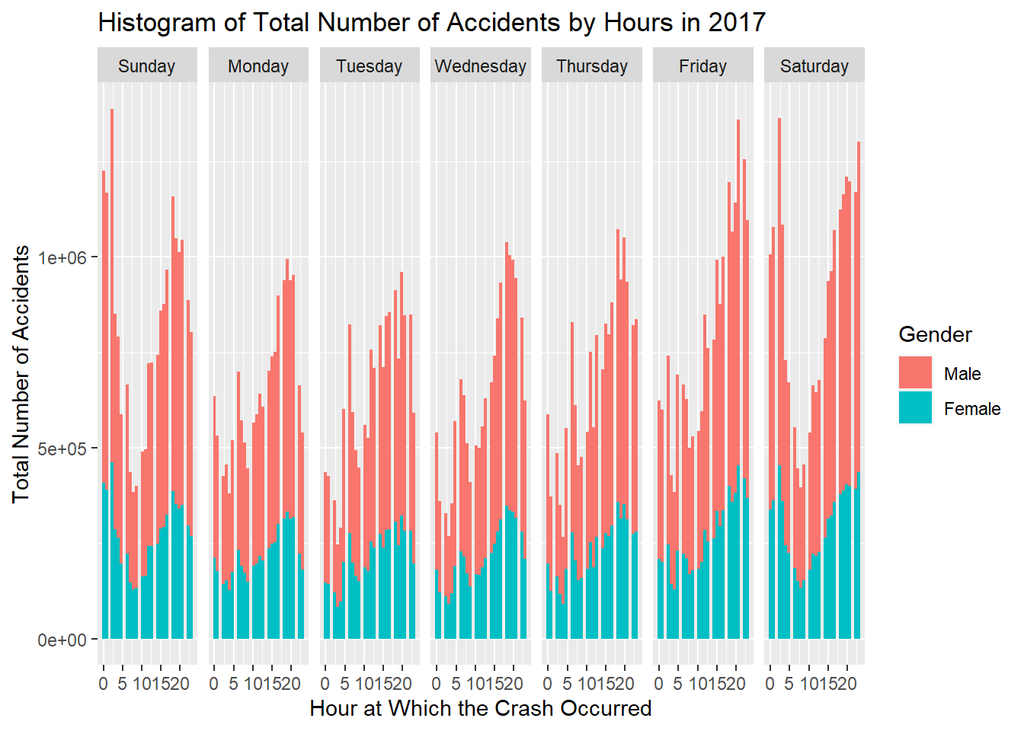

```r
# Tally the number of accidents by DAY_WEEK, HOUR, and SEX
acc_person_vis = acc_person %>%
  group_by(DAY_WEEK, HOUR, SEX) %>%
  summarise(total_acc = n()) %>%
  arrange(desc(total_acc))

# Exclude unreported or unknown observations
acc_person_vis = acc_person_vis %>%
  filter(SEX %in% c(1, 2),
         HOUR != 99)

# Convert SEX from numeric to factor
acc_person_vis$SEX = as.factor(acc_person_vis$SEX)
levels(acc_person_vis$SEX) =  c("Male", "Female")

# Histogram
acc_person_vis %>%
  ggplot(aes(x = HOUR, weight = total_acc, fill = SEX)) +
  geom_histogram() +
  facet_grid(~DAY_WEEK) +
  ggtitle('Histogram of Total Number of Accidents by Hours in 2017') +
  xlab('Hour at Which the Crash Occurred') +
  ylab('Total Number of Accidents') +
  labs(fill = 'Gender')
```

**7. Now plot a choropleth map of the number of deaths on a county level.**

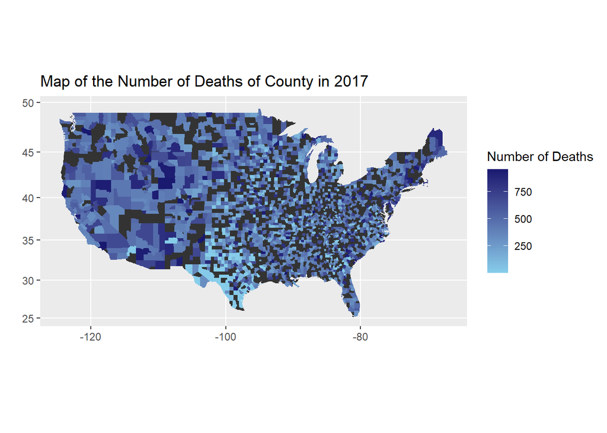

```r
# counties
counties <- map_data('county')

# acc_death
acc_death = acc %>%
  group_by(COUNTY) %>%
  summarise(number_deaths = sum(FATALS))

# Clean
glc_state$`County Code` = as.numeric(glc_state$`County Code`)

# acc_death_color for map
acc_death_color = acc_death %>%
  left_join(glc_state %>%
              select(c('County Name', 'County Code')),
            by = c('COUNTY' = 'County Code')) %>%
  mutate(`County Name` = tolower(`County Name`)) %>%
  unique() %>%
  left_join(counties, by = c('County Name' = 'subregion'))

# Create a map
ggplot(counties, aes(x = long, y = lat)) +
  geom_polygon(aes(group = group)) +
  geom_polygon(data = acc_death_color,
               aes(x = long, y = lat, group = group, fill = number_deaths)) +
  coord_map() +
  ggtitle('Map of the Number of Deaths of County in 2017') +
  xlab(' ') +
  ylab(' ') +
  labs(fill = 'Number of Deaths') +
  scale_fill_gradient(low = "skyblue", high = "midnightblue")
```

The map above shows the number of deaths in each county. The darker colors mean the higher number of deaths. The number of deaths was calculated by the FATALS variable in the acc data frame because it says “the data element “Fatalities” (FATALS) in the Accident data file provides the number of deaths for the entire crash" in the FARS Analytical User’s Manual.

**8. Is summer or winter more dangerous? Does this depend on states? Explore and explain.**

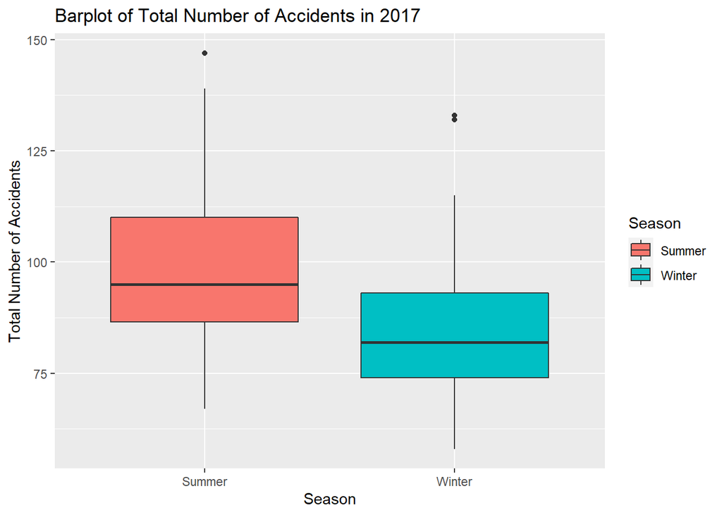

```r
# Clean
acc_season = acc %>%
  unite('date', c('MONTH', 'DAY', 'YEAR'), sep = "/")

# Convert
acc_season$date = mdy(acc_season$date)

# Date & Season
acc_season = acc_season %>%
  filter((date <= mdy('03/20/2017')) |
            ((date >= mdy('06/20/2017')) & (date <= mdy('09/22/2017'))) |
            (date >= mdy('12/21/2017'))) %>%
  mutate(season = ifelse((date >= mdy('06/20/2017')) & (date <= mdy('09/22/2017')),
                         'Summer', 'Winter'))

# Total number of accidents on each date (Overall)
acc_season_overall = acc_season %>%
  group_by(date, season) %>%
  summarise(total_acc = n())

# Boxplot
ggplot(acc_season_overall, aes(x = season, y = total_acc, fill = season)) +
  geom_boxplot() +
  ggtitle('Barplot of Total Number of Accidents in 2017') +
  xlab('Season') +
  ylab('Total Number of Accidents') +
  labs(fill = 'Season')
```

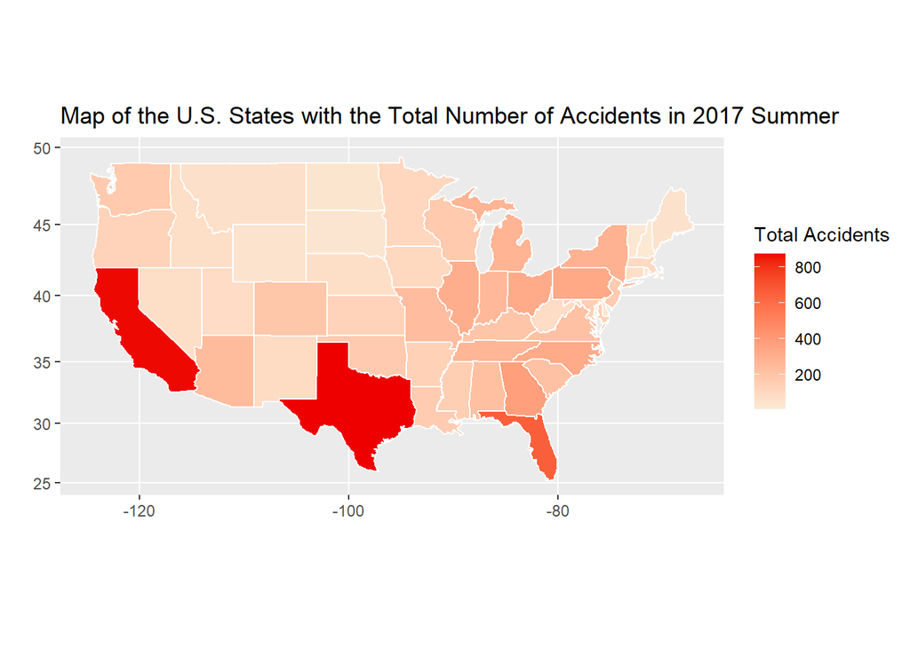

```r
# Total number of accidents on each date (By State)
acc_season_state = acc_season %>%
  group_by(STATE, season) %>%
  summarise(total_acc = n())

# Join
acc_season_state_text = acc_season_state %>%
  left_join(glc_state %>%
              select(c('State Name', 'State Code')),
            by = c('STATE' = 'State Code')) %>%
  unique() %>%
  mutate(`State Name` = tolower(`State Name`)) %>%
  left_join(states,
            by = c('State Name' = 'region'))

# Map
# Summer
ggplot(states, aes(x = long, y = lat)) +
  geom_polygon(aes(group = group)) +
  geom_polygon(data = acc_season_state_text %>%
                 filter(season == 'Summer'),
               aes(x = long, y = lat, group = group, fill = total_acc)) +
  scale_fill_gradient(low = "antiquewhite", high = "red2") +
  geom_path(aes(group = group), color = 'white') +
  coord_map() +
  ggtitle('Map of the U.S. States with the Total Number of Accidents in 2017 Summer') +
  xlab(' ') +
  ylab(' ') +
  labs(fill = 'Total Accidents')
```

[figure not shown]

```r
# Winter
ggplot(states, aes(x = long, y = lat)) +
  geom_polygon(aes(group = group)) +
  geom_polygon(data = acc_season_state_text %>%
                 filter(season == 'Winter'),
               aes(x = long, y = lat, group = group, fill = total_acc)) +
  scale_fill_gradient(low = "skyblue", high = "midnightblue") +
  geom_path(aes(group = group), color = 'white') +
  coord_map() +
  ggtitle('Map of the U.S. States with the Total Number of Accidents in 2017 Summer') +
  xlab(' ') +
  ylab(' ') +
  labs(fill = 'Total Accidents')
```

In 2017, Summer officially started on June 20 and ended on September 22, and Winter officially started on December 21 and ended on March 20, 2018. Additionally, the Winter of 2016 officially ended on March 20, 2017. Since the data sets only contain the accidents in 2017, I considered the Winter period from January 1 to March 20 and from December 21 to December 31. In order define “the level of danger”, the total number of accidents was used.

Based on the box plot, the overall pattern can be detected. There were more number of accidents over the Summer than the Winter. From the maps, more detailed information can be obtained, on a state level. The Summer data is colored in red, and the Winter data is colored in blue. In both maps, the darker colors indicate the higher number of accidents. It is very clear that the number of accidents were the highest in California, Texas, and Florida regardless of the season. That should not be surprising, as those states have both very high population and visitor counts and this study only deals with numbers of accidents, not proportions.